# Regularization Teachniques

## Imports

Please note: for this tutorial we are using the HCAIM Data sets for teaching ethical AI, the Census Dataset.

This was adapted from: https://scikit-learn.org/stable/modules/generated/sklearn.datasets.load_boston.html

Please note that this dataset is being used as it is a common dataset with ethical concerns. One example is the class bias. None of these have been adderssed for this tutorial.

The aim of this tutorial is to get an understanding of the effects of Regularization Teachniques.

```python
import pandas as pd
import matplotlib.pyplot as plt
from numpy import*
from sklearn import*


# sklearn 10FCV
from sklearn.model_selection import KFold
from sklearn.preprocessing import LabelEncoder
from sklearn.model_selection import cross_val_score
from sklearn.model_selection import cross_val_predict
from sklearn.model_selection import train_test_split


# Keras
import tensorflow as tf
from tensorflow import keras
import numpy as np
from tensorflow.keras.models import Sequential
from tensorflow.keras.layers import Dense
from tensorflow.keras.layers import Dropout
from tensorflow.keras.layers import GaussianNoise
from tensorflow.keras.callbacks import ModelCheckpoint
from tensorflow.keras.callbacks import EarlyStopping

from tensorflow.keras.wrappers.scikit_learn import KerasClassifier
from sklearn.model_selection import GridSearchCV

seed = 1
# fix random seed for reproducibility
np.random.seed(seed)
tf.random.set_seed(seed)


filename = "adult.csv"
data = pd.read_csv(filename)

plt.rcParams["figure.figsize"] = (12,8)
```

## Step 1 - Data pre-processing

Some of the columns are currently categorical. They also contain unknow values where some are identified by "?". For this tutorial, the data is pre-processed:

- The dataset is labelled encoded (including missing data as the same value, for example "?")
- The dataset is normalised

While additional pre-process and investigations could have been (and should be) conducted, for this tutorial on hyperparameter tuning which focuses on the effects of specific changes for each hyperparameter, this addiotnal pre-processing was not conducted, but can and should be for the lab.

```python
# Used to label encode categorical values

labelencoder = LabelEncoder()

print("\n\nColumn Names & formatting:\n")


for col in data.columns.values.tolist():
    if data[col].dtype == "object" or data[col].dtype == "bool":
        print("{:<30}".format(col), ":", "{:<30}".format(str(data[col].dtype)) , "Formatting to LabelEncoding")
        data[col] = labelencoder.fit_transform(data[col])
    else:
        print("{:<30}".format(col), ":", "{:<30}".format(str(data[col].dtype)) , "No formatting required.")


# Normalizing the input values (excluding the class value)

# Convert to array
array = data.values

# get seperated input and classifies, using a deep copy of a list
X = array[:,0:14]
Y = array[:,14]

scaler = preprocessing.Normalizer().fit(X)
normalizedX = scaler.transform(X)
```

```
Column Names & formatting:

age                            : int64                          No formatting required.
workclass                      : object                         Formatting to LabelEncoding
fnlwgt                         : int64                          No formatting required.
education                      : object                         Formatting to LabelEncoding
education.num                  : int64                          No formatting required.
marital.status                 : object                         Formatting to LabelEncoding
occupation                     : object                         Formatting to LabelEncoding
relationship                   : object                         Formatting to LabelEncoding
race                           : object                         Formatting to LabelEncoding
sex                            : object                         Formatting to LabelEncoding
capital.gain                   : int64                          No formatting required.
capital.loss                   : int64                          No formatting required.
hours.per.week                 : int64                          No formatting required.
native.country                 : object                         Formatting to LabelEncoding
income                         : object                         Formatting to LabelEncoding
```

## Step 2 - Bias and Weight Initialization

We will look at two (Normal and Uniform) where all other options can be found at: https://keras.io/api/layers/initializers/

### Weight Initialization

- Normal (Gaussian)
- Uniform

**Note, you can also add seed values to this function.**

#### Convergence model from Hyperparameter Tutorial (default weight initializer - glorot uniform based)

```
Train on 21815 samples, validate on 10746 samples
```

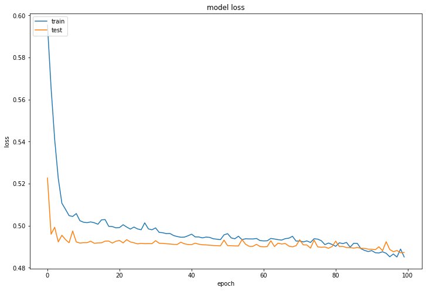

```python
# fix random seed for reproducibility
seed = 1
np.random.seed(seed)
tf.random.set_seed(seed) # for TF this needs to be run per cell.


model = Sequential()
model.add(Dense(1000, input_dim=14, activation='relu'))
model.add(Dense(100, activation='relu'))
model.add(Dense(100, activation='relu'))
model.add(Dense(50, activation='relu'))
model.add(Dense(1, activation='sigmoid'))


# Compile model
model.compile(loss='binary_crossentropy', optimizer="adam", metrics=['acc'])

# Fit the model, but this time store the history (that is accuracy and loss for each Epoch)
results = model.fit(normalizedX, Y, validation_split=0.33, epochs=100, batch_size=1000, verbose=1, shuffle=True)


# summarize history for loss
plt.plot(results.history['loss'])
plt.plot(results.history['val_loss'])
plt.title('model loss')
plt.ylabel('loss')
plt.xlabel('epoch')
plt.legend(['train', 'test'], loc='upper left')
plt.show()
```

#### Normal Distribution Weight initializers

GlorotNormal

```
Train on 21815 samples, validate on 10746 samples
```

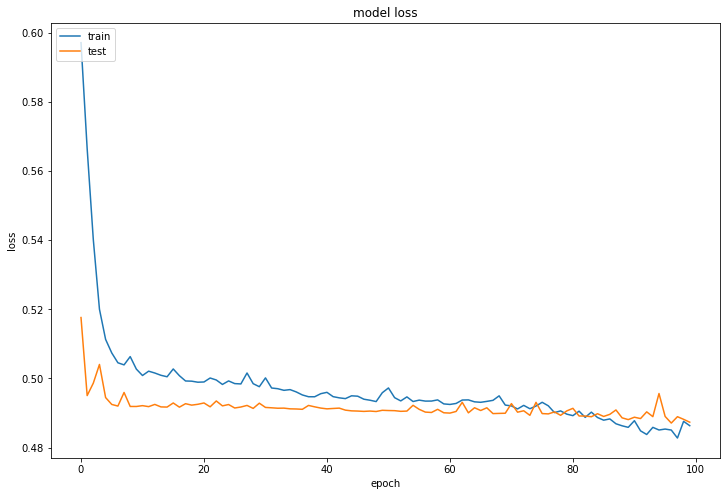

```python
# fix random seed for reproducibility
seed = 1
np.random.seed(seed)
tf.random.set_seed(seed) # for TF this needs to be run per cell.


model = Sequential()
model.add(Dense(1000, input_dim=14, activation='relu', kernel_initializer="GlorotNormal"))
model.add(Dense(100, activation='relu', kernel_initializer="GlorotNormal"))
model.add(Dense(100, activation='relu' , kernel_initializer="GlorotNormal"))
model.add(Dense(50, activation='relu', kernel_initializer="GlorotNormal"))
model.add(Dense(1, activation='sigmoid'))


# Compile model
model.compile(loss='binary_crossentropy', optimizer="adam", metrics=['acc'])

# Fit the model, but this time store the history (that is accuracy and loss for each Epoch)
results = model.fit(normalizedX, Y, validation_split=0.33, epochs=100, batch_size=1000, verbose=1, shuffle=True)


# summarize history for loss
plt.plot(results.history['loss'])
plt.plot(results.history['val_loss'])
plt.title('model loss')
plt.ylabel('loss')
plt.xlabel('epoch')
plt.legend(['train', 'test'], loc='upper left')
plt.show()
```

#### Uniform Weight initializers

GlorotUniform

```
Train on 21815 samples, validate on 10746 samples
```

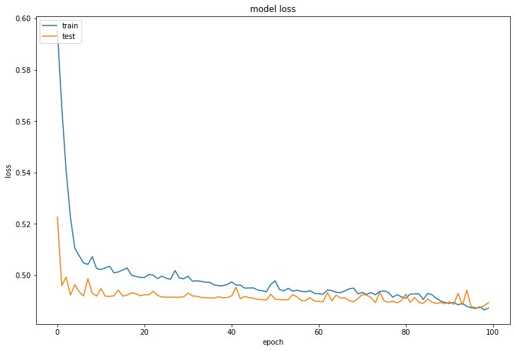

```python
# fix random seed for reproducibility
seed = 1
np.random.seed(seed)
tf.random.set_seed(seed) # for TF this needs to be run per cell.


model = Sequential()
model.add(Dense(1000, input_dim=14, activation='relu', kernel_initializer="GlorotUniform"))
model.add(Dense(100, activation='relu', kernel_initializer="GlorotUniform"))
model.add(Dense(100, activation='relu' , kernel_initializer="GlorotUniform"))
model.add(Dense(50, activation='relu', kernel_initializer="GlorotUniform"))
model.add(Dense(1, activation='sigmoid'))


# Compile model
model.compile(loss='binary_crossentropy', optimizer="adam", metrics=['acc'])

# Fit the model, but this time store the history (that is accuracy and loss for each Epoch)
results = model.fit(normalizedX, Y, validation_split=0.33, epochs=100, batch_size=1000, verbose=1, shuffle=True)


# summarize history for loss
plt.plot(results.history['loss'])
plt.plot(results.history['val_loss'])
plt.title('model loss')
plt.ylabel('loss')
plt.xlabel('epoch')
plt.legend(['train', 'test'], loc='upper left')
plt.show()
```

### Bias

https://keras.io/api/layers/core_layers/dense/

#### The use of Bias

```
Train on 21815 samples, validate on 10746 samples
```

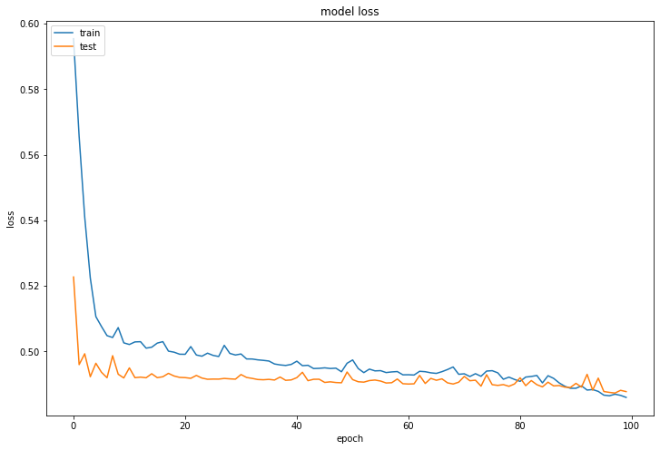

```python
# fix random seed for reproducibility
seed = 1
np.random.seed(seed)
tf.random.set_seed(seed) # for TF this needs to be run per cell.


model = Sequential()
model.add(Dense(1000, input_dim=14, activation='relu', use_bias = True))
model.add(Dense(100, activation='relu', use_bias = True))
model.add(Dense(100, activation='relu', use_bias = True))
model.add(Dense(50, activation='relu' , use_bias = True))
model.add(Dense(1, activation='sigmoid'))


# Compile model
model.compile(loss='binary_crossentropy', optimizer="adam", metrics=['acc'])

# Fit the model, but this time store the history (that is accuracy and loss for each Epoch)
results = model.fit(normalizedX, Y, validation_split=0.33, epochs=100, batch_size=1000, verbose=1, shuffle=True)


# summarize history for loss
plt.plot(results.history['loss'])
plt.plot(results.history['val_loss'])
plt.title('model loss')
plt.ylabel('loss')
plt.xlabel('epoch')
plt.legend(['train', 'test'], loc='upper left')
plt.show()
```

#### No Bias

```
Train on 21815 samples, validate on 10746 samples
```

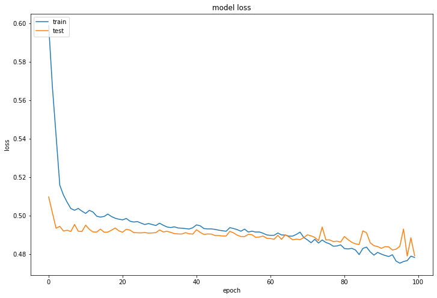

```python
# fix random seed for reproducibility
seed = 1
np.random.seed(seed)
tf.random.set_seed(seed) # for TF this needs to be run per cell.


model = Sequential()
model.add(Dense(1000, input_dim=14, activation='relu', use_bias = False))
model.add(Dense(100, activation='relu', use_bias = False))
model.add(Dense(100, activation='relu', use_bias = False))
model.add(Dense(50, activation='relu' , use_bias = False))
model.add(Dense(1, activation='sigmoid'))


# Compile model
model.compile(loss='binary_crossentropy', optimizer="adam", metrics=['acc'])

# Fit the model, but this time store the history (that is accuracy and loss for each Epoch)
results = model.fit(normalizedX, Y, validation_split=0.33, epochs=100, batch_size=1000, verbose=1, shuffle=True)


# summarize history for loss
plt.plot(results.history['loss'])
plt.plot(results.history['val_loss'])
plt.title('model loss')
plt.ylabel('loss')
plt.xlabel('epoch')
plt.legend(['train', 'test'], loc='upper left')
plt.show()
```

## Step 3 - Co-adaption

We will look at two techniques that will help regularize the network, that is to reduce the effects of co-adaption and over fitting.

### Dropout

Added to both the input layer and hidden layers using defaul 20%

https://keras.io/api/layers/regularization_layers/dropout/

```
Train on 21815 samples, validate on 10746 samples
```

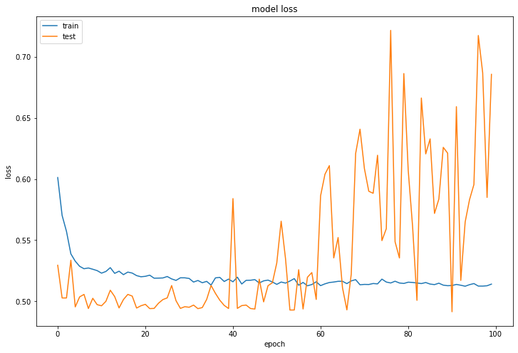

```python
# fix random seed for reproducibility
seed = 1
np.random.seed(seed)
tf.random.set_seed(seed) # for TF this needs to be run per cell.


model = Sequential()
model.add(Dropout(0.2, input_shape =(14,)))
model.add(Dense(1000, activation='relu'))
model.add(Dropout(0.2))
model.add(Dense(100, activation='relu'))
model.add(Dropout(0.2))
model.add(Dense(100, activation='relu'))
model.add(Dropout(0.2))
model.add(Dense(50, activation='relu'))
model.add(Dropout(0.2))
model.add(Dense(1, activation='sigmoid'))


# Compile model
model.compile(loss='binary_crossentropy', optimizer="adam", metrics=['acc'])

# Fit the model, but this time store the history (that is accuracy and loss for each Epoch)
results = model.fit(normalizedX, Y, validation_split=0.33, epochs=100, batch_size=1000, verbose=1, shuffle=True)


# summarize history for loss
plt.plot(results.history['loss'])
plt.plot(results.history['val_loss'])
plt.title('model loss')
plt.ylabel('loss')
plt.xlabel('epoch')
plt.legend(['train', 'test'], loc='upper left')
plt.show()
```

### Noise

Added to both the hidden layers using defaul 0.1 STD

https://keras.io/api/layers/regularization_layers/gaussian_noise/

```
Train on 21815 samples, validate on 10746 samples
```

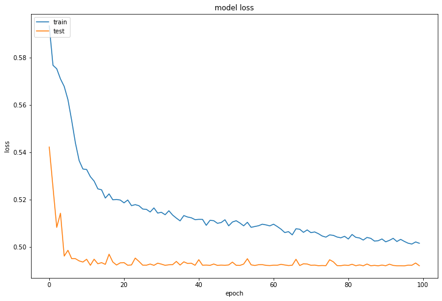

```python
# fix random seed for reproducibility
seed = 1
np.random.seed(seed)
tf.random.set_seed(seed) # for TF this needs to be run per cell.


model = Sequential()
model.add(Dense(1000, input_dim=14, activation='relu'))
model.add(GaussianNoise(0.1))
model.add(Dense(100, activation='relu'))
model.add(GaussianNoise(0.1))
model.add(Dense(100, activation='relu'))
model.add(GaussianNoise(0.1))
model.add(Dense(50, activation='relu'))
model.add(GaussianNoise(0.1))
model.add(Dense(1, activation='sigmoid'))


# Compile model
model.compile(loss='binary_crossentropy', optimizer="adam", metrics=['acc'])

# Fit the model, but this time store the history (that is accuracy and loss for each Epoch)
results = model.fit(normalizedX, Y, validation_split=0.33, epochs=100, batch_size=1000, verbose=1, shuffle=True)


# summarize history for loss
plt.plot(results.history['loss'])
plt.plot(results.history['val_loss'])
plt.title('model loss')
plt.ylabel('loss')
plt.xlabel('epoch')
plt.legend(['train', 'test'], loc='upper left')
plt.show()
```

## Step 4 - Callbacks

Callbacks are useful tools during production training, and for significantly heaving Regularization techniques such as gridsearch. Also if the model fails during training, not all is lost if for example you save the weights. Early stopping can also be used to significantly speed up training and intensive gridsearches.

https://keras.io/api/callbacks/

### Weight Saving (manually and using callbacks)

#### Manually saving the weights (these can be opened with any HDF5 reader).

*Note we will be looking at saving the full model as a Tensorflow model in production.*

```
Train on 21815 samples, validate on 10746 samples
```

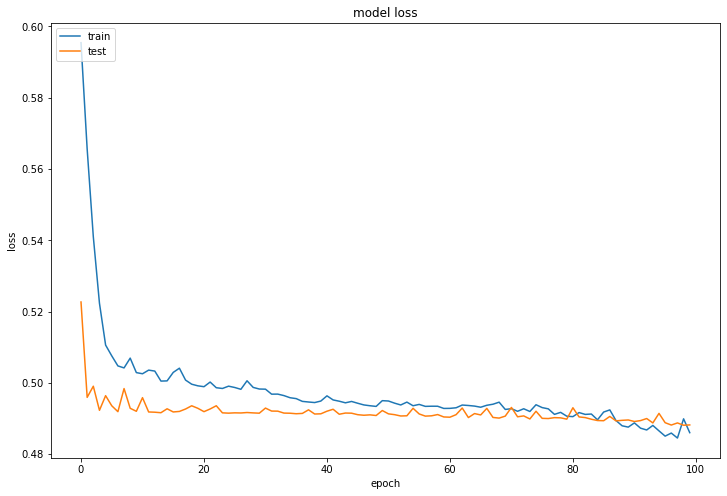

```
Weights Saved as: myModel.HDF5
```

```python
# fix random seed for reproducibility
seed = 1
np.random.seed(seed)
tf.random.set_seed(seed) # for TF this needs to be run per cell.


model = Sequential()
model.add(Dense(1000, input_dim=14, activation='relu'))
model.add(Dense(100, activation='relu'))
model.add(Dense(100, activation='relu'))
model.add(Dense(50, activation='relu'))
model.add(Dense(1, activation='sigmoid'))


# Compile model
model.compile(loss='binary_crossentropy', optimizer="adam", metrics=['acc'])

# Fit the model, but this time store the history (that is accuracy and loss for each Epoch)
results = model.fit(normalizedX, Y, validation_split=0.33, epochs=100, batch_size=1000, verbose=1, shuffle=True)


# summarize history for loss
plt.plot(results.history['loss'])
plt.plot(results.history['val_loss'])
plt.title('model loss')
plt.ylabel('loss')
plt.xlabel('epoch')
plt.legend(['train', 'test'], loc='upper left')
plt.show()


# Saving the weights:
fileName = "myModel.HDF5"

model.save_weights(fileName)
print("Weights Saved as:", fileName)
```

#### Automatically saving the weights (these can be opened with any HDF5 reader) using best model.

```
Train on 21815 samples, validate on 10746 samples
Epoch 00001: acc improved from -inf to 0.73633, saving model to myBest.hdf5
Epoch 00002: acc improved from 0.73633 to 0.74155, saving model to myBest.hdf5
Epoch 00003: acc improved from 0.74155 to 0.75631, saving model to myBest.hdf5
Epoch 00004: acc improved from 0.75631 to 0.77969, saving model to myBest.hdf5
Epoch 00005: acc improved from 0.77969 to 0.78602, saving model to myBest.hdf5
Epoch 00006: acc improved from 0.78602 to 0.78767, saving model to myBest.hdf5
Epoch 00007: acc did not improve from 0.78767
Epoch 00008: acc did not improve from 0.78767
Epoch 00009: acc did not improve from 0.78767
Epoch 00010: acc improved from 0.78767 to 0.78849, saving model to myBest.hdf5
Epoch 00011: acc improved from 0.78849 to 0.78859, saving model to myBest.hdf5
Epoch 00012: acc improved from 0.78859 to 0.78872, saving model to myBest.hdf5
Epoch 00013: acc did not improve from 0.78872
Epoch 00014: acc did not improve from 0.78872
Epoch 00015: acc did not improve from 0.78872
Epoch 00016: acc improved from 0.78872 to 0.78946, saving model to myBest.hdf5
Epoch 00017: acc did not improve from 0.78946
Epoch 00018: acc did not improve from 0.78946
Epoch 00019: acc improved from 0.78946 to 0.79033, saving model to myBest.hdf5
Epoch 00020: acc did not improve from 0.79033
Epoch 00021: acc did not improve from 0.79033
Epoch 00022: acc did not improve from 0.79033
Epoch 00023: acc did not improve from 0.79033
Epoch 00024: acc improved from 0.79033 to 0.79065, saving model to myBest.hdf5
Epoch 00025: acc did not improve from 0.79065
Epoch 00026: acc improved from 0.79065 to 0.79074, saving model to myBest.hdf5
Epoch 00027: acc improved from 0.79074 to 0.79120, saving model to myBest.hdf5
Epoch 00028: acc did not improve from 0.79120
Epoch 00029: acc did not improve from 0.79120
Epoch 00030: acc did not improve from 0.79120
Epoch 00031: acc did not improve from 0.79120
Epoch 00032: acc did not improve from 0.79120
Epoch 00033: acc did not improve from 0.79120
Epoch 00034: acc improved from 0.79120 to 0.79152, saving model to myBest.hdf5
Epoch 00035: acc did not improve from 0.79152
Epoch 00036: acc did not improve from 0.79152
Epoch 00037: acc did not improve from 0.79152
Epoch 00038: acc did not improve from 0.79152
Epoch 00039: acc improved from 0.79152 to 0.79157, saving model to myBest.hdf5
```

[output cut: 46 more lines]

```
Epoch 00086: acc did not improve from 0.79395
Epoch 00087: acc did not improve from 0.79395
Epoch 00088: acc did not improve from 0.79395
Epoch 00089: acc did not improve from 0.79395
Epoch 00090: acc did not improve from 0.79395
Epoch 00091: acc did not improve from 0.79395
Epoch 00092: acc did not improve from 0.79395
Epoch 00093: acc did not improve from 0.79395
Epoch 00094: acc did not improve from 0.79395
Epoch 00095: acc did not improve from 0.79395
Epoch 00096: acc improved from 0.79395 to 0.79455, saving model to myBest.hdf5
Epoch 00097: acc improved from 0.79455 to 0.79505, saving model to myBest.hdf5
Epoch 00098: acc did not improve from 0.79505
Epoch 00099: acc did not improve from 0.79505
Epoch 00100: acc did not improve from 0.79505
```

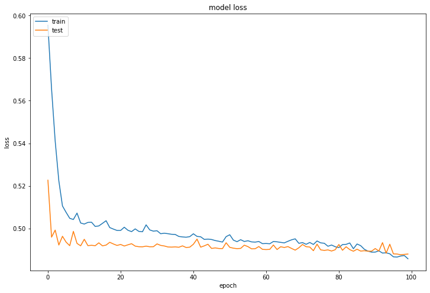

```python
# fix random seed for reproducibility
seed = 1
np.random.seed(seed)
tf.random.set_seed(seed) # for TF this needs to be run per cell.


model = Sequential()
model.add(Dense(1000, input_dim=14, activation='relu'))
model.add(Dense(100, activation='relu'))
model.add(Dense(100, activation='relu'))
model.add(Dense(50, activation='relu'))
model.add(Dense(1, activation='sigmoid'))


# Compile model
model.compile(loss='binary_crossentropy', optimizer="adam", metrics=['acc'])


# Checkpointing
checkpoint = ModelCheckpoint("myBest.hdf5", monitor='acc', save_best_only=True, mode="max", verbose=1)
callbacks_list = [checkpoint]


# Fit the model, but this time store the history (that is accuracy and loss for each Epoch)
results = model.fit(normalizedX, Y, validation_split=0.33, epochs=100, batch_size=1000, verbose=1, shuffle=True, callbacks=callbacks_list)


# summarize history for loss
plt.plot(results.history['loss'])
plt.plot(results.history['val_loss'])
plt.title('model loss')
plt.ylabel('loss')
plt.xlabel('epoch')
plt.legend(['train', 'test'], loc='upper left')
plt.show()
```

### Early stopping

https://keras.io/api/callbacks/early_stopping/

patience: Number of epochs with no improvement after which training will be stopped.

```
Train on 21815 samples, validate on 10746 samples
Epoch 00001: acc improved from -inf to 0.73633, saving model to myBest.hdf5
Epoch 00002: acc improved from 0.73633 to 0.74155, saving model to myBest.hdf5
Epoch 00003: acc improved from 0.74155 to 0.75631, saving model to myBest.hdf5
Epoch 00004: acc improved from 0.75631 to 0.77974, saving model to myBest.hdf5
Epoch 00005: acc improved from 0.77974 to 0.78597, saving model to myBest.hdf5
Epoch 00006: acc improved from 0.78597 to 0.78785, saving model to myBest.hdf5
Epoch 00007: acc did not improve from 0.78785
Epoch 00008: acc did not improve from 0.78785
Epoch 00009: acc did not improve from 0.78785
Epoch 00010: acc improved from 0.78785 to 0.78854, saving model to myBest.hdf5
Epoch 00011: acc improved from 0.78854 to 0.78914, saving model to myBest.hdf5
Epoch 00012: acc did not improve from 0.78914
```

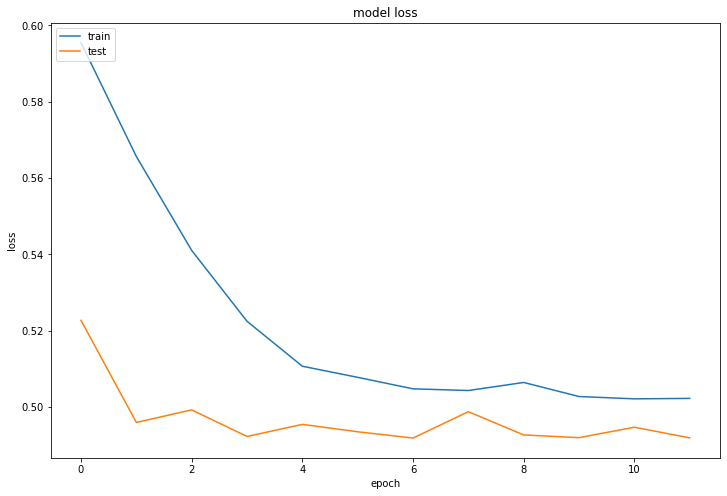

```python
# fix random seed for reproducibility
seed = 1
np.random.seed(seed)
tf.random.set_seed(seed) # for TF this needs to be run per cell.


model = Sequential()
model.add(Dense(1000, input_dim=14, activation='relu'))
model.add(Dense(100, activation='relu'))
model.add(Dense(100, activation='relu'))
model.add(Dense(50, activation='relu'))
model.add(Dense(1, activation='sigmoid'))


# Compile model
model.compile(loss='binary_crossentropy', optimizer="adam", metrics=['acc'])


# Checkpointing
checkpoint = ModelCheckpoint("myBest.hdf5", monitor='acc', save_best_only=True, mode="max", verbose=1)
earlystopping = EarlyStopping(monitor="val_loss",patience= 5)


callbacks_list = [checkpoint, earlystopping]


# Fit the model, but this time store the history (that is accuracy and loss for each Epoch)
results = model.fit(normalizedX, Y, validation_split=0.33, epochs=100, batch_size=1000, verbose=1, shuffle=True, callbacks=callbacks_list)


# summarize history for loss
plt.plot(results.history['loss'])
plt.plot(results.history['val_loss'])
plt.title('model loss')
plt.ylabel('loss')
plt.xlabel('epoch')
plt.legend(['train', 'test'], loc='upper left')
plt.show()
```

## Step 5 - Grid Search

```python
# fix random seed for reproducibility
seed = 1
np.random.seed(seed)
tf.random.set_seed(seed) # for TF this needs to be run per cell.


def gs_model(optimizerIn='adam', initIn='GlorotUniform'):
    model = Sequential()
    model.add(Dense(1000, input_dim=14, activation='relu', kernel_initializer=initIn))
    model.add(Dense(100, activation='relu', kernel_initializer=initIn))
    model.add(Dense(100, activation='relu', kernel_initializer=initIn))
    model.add(Dense(50, activation='relu' , kernel_initializer=initIn))
    model.add(Dense(1, activation='sigmoid'))
     # Compile model
    model.compile(loss='binary_crossentropy', optimizer=optimizerIn, metrics=['acc'])
    return model


model = KerasClassifier(build_fn=gs_model)

# grid search epochs, batch size and optimizer
optimizers = ['rmsprop', 'adam']
inits = ['normal', 'uniform']
epochs = [100]
batches = [1000, 2000]


# Checkpointing
checkpoint = ModelCheckpoint("myBest.hdf5", monitor='acc', save_best_only=True, mode="max", verbose=1)
earlystopping = EarlyStopping(monitor="loss",patience= 5)
callbacks_list = [checkpoint, earlystopping]


param_grid = dict(optimizerIn=optimizers, epochs=epochs, batch_size=batches, initIn=inits)

grid = GridSearchCV(estimator=model, param_grid=param_grid)
grid_result = grid.fit(normalizedX, Y, callbacks=callbacks_list)

# summarize results
print("Best: %f using %s" % (grid_result.best_score_, grid_result.best_params_))
means = grid_result.cv_results_['mean_test_score']
stds = grid_result.cv_results_['std_test_score']
params = grid_result.cv_results_['params']

for mean, stdev, param in zip(means, stds, params):
    print("%f (%f) with: %r" % (mean, stdev, param))
```

```
Train on 26048 samples
Epoch 00001: acc improved from -inf to 0.81043, saving model to myBest.hdf5
Epoch 00002: acc did not improve from 0.81043
Epoch 00003: acc did not improve from 0.81043
Epoch 00004: acc did not improve from 0.81043
Epoch 00005: acc did not improve from 0.81043
Epoch 00006: acc did not improve from 0.81043
Epoch 00007: acc did not improve from 0.81043
Epoch 00008: acc did not improve from 0.81043
Epoch 00009: acc did not improve from 0.81043
Epoch 00010: acc did not improve from 0.81043
Epoch 00011: acc did not improve from 0.81043
Epoch 00012: acc did not improve from 0.81043
Train on 26049 samples
Epoch 00001: acc did not improve from 0.81043
Epoch 00002: acc did not improve from 0.81043
Epoch 00003: acc did not improve from 0.81043
Epoch 00004: acc did not improve from 0.81043
Epoch 00005: acc did not improve from 0.81043
Epoch 00006: acc did not improve from 0.81043
Epoch 00007: acc did not improve from 0.81043
Epoch 00008: acc did not improve from 0.81043
Epoch 00009: acc did not improve from 0.81043
Epoch 00010: acc did not improve from 0.81043
Epoch 00011: acc did not improve from 0.81043
Epoch 00012: acc did not improve from 0.81043
Epoch 00013: acc did not improve from 0.81043
Epoch 00014: acc did not improve from 0.81043
Epoch 00015: acc did not improve from 0.81043
Epoch 00016: acc did not improve from 0.81043
Epoch 00017: acc did not improve from 0.81043
Epoch 00018: acc did not improve from 0.81043
Epoch 00019: acc did not improve from 0.81043
Epoch 00020: acc did not improve from 0.81043
Epoch 00021: acc did not improve from 0.81043
Epoch 00022: acc did not improve from 0.81043
Epoch 00023: acc did not improve from 0.81043
Epoch 00024: acc did not improve from 0.81043
Epoch 00025: acc did not improve from 0.81043
Epoch 00026: acc did not improve from 0.81043
```

[output cut: 1026 more lines]

```
Epoch 00043: acc did not improve from 0.81043
Epoch 00044: acc did not improve from 0.81043
Epoch 00045: acc did not improve from 0.81043
Epoch 00046: acc did not improve from 0.81043
Epoch 00047: acc did not improve from 0.81043
Epoch 00048: acc did not improve from 0.81043
Best: 0.759197 using {'batch_size': 1000, 'epochs': 100, 'initIn': 'normal', 'optimizerIn': 'rmsprop'}
0.759197 (0.102498) with: {'batch_size': 1000, 'epochs': 100, 'initIn': 'normal', 'optimizerIn': 'rmsprop'}
0.759197 (0.102498) with: {'batch_size': 1000, 'epochs': 100, 'initIn': 'normal', 'optimizerIn': 'adam'}
0.759197 (0.102498) with: {'batch_size': 1000, 'epochs': 100, 'initIn': 'uniform', 'optimizerIn': 'rmsprop'}
0.759197 (0.102498) with: {'batch_size': 1000, 'epochs': 100, 'initIn': 'uniform', 'optimizerIn': 'adam'}
0.759197 (0.102498) with: {'batch_size': 2000, 'epochs': 100, 'initIn': 'normal', 'optimizerIn': 'rmsprop'}
0.759197 (0.102498) with: {'batch_size': 2000, 'epochs': 100, 'initIn': 'normal', 'optimizerIn': 'adam'}
0.759197 (0.102498) with: {'batch_size': 2000, 'epochs': 100, 'initIn': 'uniform', 'optimizerIn': 'rmsprop'}
0.759197 (0.102498) with: {'batch_size': 2000, 'epochs': 100, 'initIn': 'uniform', 'optimizerIn': 'adam'}
```

## Step 6 - Additional Checks for overfitting

### De-normalizing the data

In addition you could take a step further and conduct a hypothesis test on the two results

```python
print("Raw data\n")
print(X[:3])

print("\n\n\nNormalized data\n")
print(normalizedX[:3])
```

```
Raw data

[[    90      0  77053     11      9      6      0      1      4      0
       0   4356     40     39]
 [    82      4 132870     11      9      6      4      1      4      0
       0   4356     18     39]
 [    66      0 186061     15     10      6      0      4      2      0
       0   4356     40     39]]



Normalized data

[[1.16616408e-03 0.00000000e+00 9.98404896e-01 1.42531165e-04
  1.16616408e-04 7.77442718e-05 0.00000000e+00 1.29573786e-05
  5.18295145e-05 0.00000000e+00 0.00000000e+00 5.64423413e-02
  5.18295145e-04 5.05337767e-04]
 [6.16813041e-04 3.00884410e-05 9.99462790e-01 8.27432128e-05
  6.76989923e-05 4.51326615e-05 3.00884410e-05 7.52211025e-06
  3.00884410e-05 0.00000000e+00 0.00000000e+00 3.27663123e-02
  1.35397985e-04 2.93362300e-04]
 [3.54625163e-04 0.00000000e+00 9.99725946e-01 8.05966279e-05
  5.37310853e-05 3.22386512e-05 0.00000000e+00 2.14924341e-05
  1.07462171e-05 0.00000000e+00 0.00000000e+00 2.34052607e-02
  2.14924341e-04 2.09551233e-04]]
```

```python
test_size = 0.33
# raw data
X_train_raw, X_test_raw, Y_train_raw, Y_test_raw  = train_test_split(X, Y, test_size=test_size, random_state=seed)

# normalized data
X_train_nor, X_test_nor, Y_train_nor, Y_test_nor  = train_test_split(normalizedX, Y, test_size=test_size, random_state=seed)
```

```
Train on 21815 samples, validate on 10746 samples
```

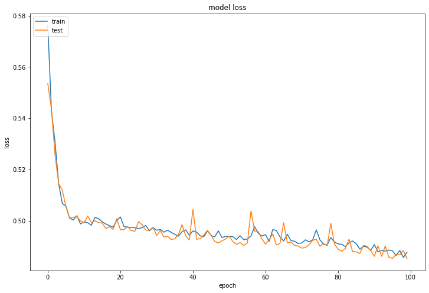

```
Performance on normalized unseen data:
79.3504536151886


Performance on raw un-normalized unseen data:
78.18723320960999
```

```python
# fix random seed for reproducibility
seed = 1
np.random.seed(seed)
tf.random.set_seed(seed) # for TF this needs to be run per cell.


model = Sequential()
model.add(Dense(1000, input_dim=14, activation='relu'))
model.add(Dense(100, activation='relu'))
model.add(Dense(100, activation='relu'))
model.add(Dense(50, activation='relu'))
model.add(Dense(1, activation='sigmoid'))


# Compile model
model.compile(loss='binary_crossentropy', optimizer="adam", metrics=['acc'])


# Fit the model, but this time store the history (that is accuracy and loss for each Epoch)
results = model.fit(X_train_nor, Y_train_nor, validation_data=(X_test_nor,Y_test_nor), epochs=100, batch_size=1000, verbose=1, shuffle=True)


# summarize history for loss
plt.plot(results.history['loss'])
plt.plot(results.history['val_loss'])
plt.title('model loss')
plt.ylabel('loss')
plt.xlabel('epoch')
plt.legend(['train', 'test'], loc='upper left')
plt.show()

print("\n\nPerformance on normalized unseen data:")
print(model.evaluate(X_test_nor,Y_test_nor)[1] *100)


print("\n\nPerformance on raw un-normalized unseen data:")
print(model.evaluate(X_test_raw,Y_test_raw)[1] *100)
```

### Adding class value as input attribute

We have used the train_test_split method to ensure that the splits are the same using the seed value.

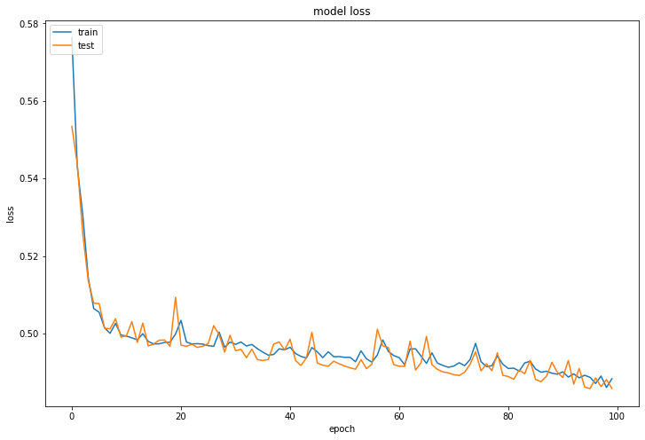

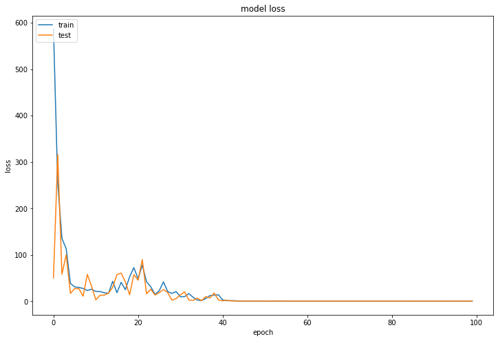

[output not shown]

```python
# Convert to array
array = data.values

# get seperated input and classifies, using a deep copy of a list
XwithY = array[:,0:15]
Y = array[:,14]

scaler = preprocessing.Normalizer().fit(XwithY)
normalizedXwithY = scaler.transform(XwithY)



test_size = 0.33
# XwithY
X_train_withY, X_test_withY, Y_train_withY, Y_test_withY  = train_test_split(XwithY, Y, test_size=test_size, random_state=seed)

# normalized data
X_train_nor, X_test_nor, Y_train_nor, Y_test_nor  = train_test_split(normalizedX, Y, test_size=test_size, random_state=seed)



# fix random seed for reproducibility
seed = 1
np.random.seed(seed)
tf.random.set_seed(seed) # for TF this needs to be run per cell.


model = Sequential()
model.add(Dense(1000, input_dim=14, activation='relu'))
model.add(Dense(100, activation='relu'))
model.add(Dense(100, activation='relu'))
model.add(Dense(50, activation='relu'))
model.add(Dense(1, activation='sigmoid'))


# Compile model
model.compile(loss='binary_crossentropy', optimizer="adam", metrics=['acc'])


# Fit the model, but this time store the history (that is accuracy and loss for each Epoch)
results = model.fit(X_train_nor, Y_train_nor, validation_data=(X_test_nor,Y_test_nor), epochs=100, batch_size=1000, verbose=0)


# summarize history for loss
plt.plot(results.history['loss'])
plt.plot(results.history['val_loss'])
plt.title('model loss')
plt.ylabel('loss')
plt.xlabel('epoch')
plt.legend(['train', 'test'], loc='upper left')
plt.show()





# fix random seed for reproducibility
seed = 1
np.random.seed(seed)
tf.random.set_seed(seed) # for TF this needs to be run per cell.


model2 = Sequential()
model2.add(Dense(1000, input_dim=15, activation='relu'))
model2.add(Dense(100, activation='relu'))
model2.add(Dense(100, activation='relu'))
model2.add(Dense(50, activation='relu'))
model2.add(Dense(1, activation='sigmoid'))


# Compile model
model2.compile(loss='binary_crossentropy', optimizer="adam", metrics=['acc'])


# Fit the model, but this time store the history (that is accuracy and loss for each Epoch)
results = model2.fit(X_train_withY, Y_train_withY, validation_data=(X_test_withY,Y_test_withY), epochs=100, batch_size=1000, verbose=0)


# summarize history for loss
plt.plot(results.history['loss'])
plt.plot(results.history['val_loss'])
plt.title('model loss')
plt.ylabel('loss')
plt.xlabel('epoch')
plt.legend(['train', 'test'], loc='upper left')
plt.show()



print("\n\nPerformance on normalized unseen data:")
print(model.evaluate(X_test_nor,Y_test_nor)[1] *100)


print("\n\nPerformance with class as attribute:")
print(model2.evaluate(X_test_withY,Y_test_withY)[1] *100)
```